# Split-Apply-Combine and Plyr

Statistical Computing, 36-350

Thursday July 26, 2018

# Last time: Fitting models to data

- Fitting models is critical to both statistical inference and prediction
- Exploratory data analysis is a very good first step and gives you a sense of what you’re dealing with before you start modeling
- Linear regression is the most basic modeling tool of all, and one of the most ubiquitous
- `lm()` allows you to fit a linear model by specifying a formula, in terms of column names of a given data frame
- Utility functions `coef()`, `fitted()`, `residuals()`, `summary()`, `plot()`, `predict()` are very handy and should be used over manual access tricks
- Logistic regression is the natural extension of linear regression to binary data; use `glm()` with `family="binomial"` and all the same utility functions
- Generalized additive models add a level of flexibility in that they allow the predictors to have nonlinear effects; use `gam()` and utility functions

# Part I

*Split-apply-combine*

# Reminder: iterating in R without `for()`

We’ve learned some tools in R for iteration without explicit `for()` loops:

- Indexing with conditionals + vectorization
- `apply()`: apply a function to rows or columns of a matrix or data frame
- `lapply()`: apply a function to elements of a list or vector
- `sapply()`: same as the above, but simplify the output (if possible)
- `tapply()`: apply a function to levels of a factor vector

# Split-apply-combine

Today we will learn a general strategy for data analysis/management that can be summmarized in three conceptual steps:

- **Split** whatever data object we have into meaningful chunks
- **Apply** the function of interest to each element in this division
- **Combine** the results into a new object of the desired structure

These are conceptual steps; often the apply and combine steps can be performed for us by a single call to the appropriate function from the `apply()` family

# Simple but powerful

Does split-apply-combine sound simple? It is, but it’s very powerful when combined with the right data structures

- As usual, compared to explicit `for()` loops, often requires far less code
- Fits nicely with our previous idea of top-down function design, simply at a broader scope
- Sets you in the right direction towards learning how to use MapReduce/Hadoop for really, really big data sets

# Strikes data set

Data set on 18 countries over 35 years (compiled by Bruce Western, in the Sociology Department at Harvard University). The measured variables:

- `country`, `year`: country and year of data collection
- `strike.volume`: days on strike per 1000 workers
- `unemployment`: unemployment rate
- `inflation`: inflation rate
- `left.parliament`: leftwing share of the goverment
- `centralization`: centralization of unions
- `density`: density of unions

```r
strikes.df =
  read.csv("https://raw.githubusercontent.com/linnylin92/36-350_public/master/dat/strikes.csv")
dim(strikes.df) # Since 18 × 35 = 630, some years missing from some countries
```

```
## [1] 625   8
```

```r
head(strikes.df)
```

```
##     country year strike.volume unemployment inflation left.parliament
## 1 Australia 1951           296          1.3      19.8            43.0
## 2 Australia 1952           397          2.2      17.2            43.0
## 3 Australia 1953           360          2.5       4.3            43.0
## 4 Australia 1954             3          1.7       0.7            47.0
## 5 Australia 1955           326          1.4       2.0            38.5
## 6 Australia 1956           352          1.8       6.3            38.5
##   centralization density
## 1      0.3748588      NA
## 2      0.3751829      NA
## 3      0.3745076      NA
## 4      0.3710170      NA
## 5      0.3752675      NA
## 6      0.3716072      NA
```

# An interesting question

Is there a relationship between a country’s ruling party alignment (left versus right) and the volume of strikes?

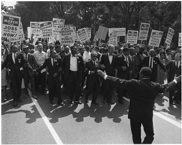

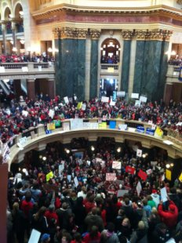

How could we approach this?

- Worst way: by hand, write 18 separate code blocks
- Bad way: explicit `for()` loop, where we loop over countries
- Best way: split appropriately, then use `sapply()`

# Work with just one chunk of data

**Step 0**: design a function that will work on one chunk of data

So let’s write code to do regression on the data from (say) just Italy

```r
strikes.df.italy = strikes.df[strikes.df$country=="Italy", ] # Data for Italy
dim(strikes.df.italy)
```

```
## [1] 35  8
```

```r
head(strikes.df.italy)
```

```
##     country year strike.volume unemployment inflation left.parliament
## 311   Italy 1951           437          8.8      14.3            37.5
## 312   Italy 1952           337          9.5       1.9            37.5
## 313   Italy 1953           545         10.0       1.4            40.2
## 314   Italy 1954           493          8.7       2.4            40.2
## 315   Italy 1955           511          7.5       2.3            40.2
## 316   Italy 1956           372          9.3       3.4            40.2
##     centralization density
## 311      0.2513799      NA
## 312      0.2489860      NA
## 313      0.2482739      NA
## 314      0.2466577      NA
## 315      0.2540366      NA
## 316      0.2457069      NA
```

```r
italy.lm = lm(strike.volume ~ left.parliament, data=strikes.df.italy)
summary(italy.lm)
```

```
##
## Call:
## lm(formula = strike.volume ~ left.parliament, data = strikes.df.italy)
##
## Residuals:
##    Min     1Q Median     3Q    Max
## -930.2 -411.6 -137.3  387.2 1901.4
##
## Coefficients:
##                 Estimate Std. Error t value Pr(>|t|)
## (Intercept)      -738.75    1200.62  -0.615    0.543
## left.parliament    40.29      27.76   1.451    0.156
##
## Residual standard error: 583.3 on 33 degrees of freedom
## Multiple R-squared:  0.05999,    Adjusted R-squared:  0.0315
## F-statistic: 2.106 on 1 and 33 DF,  p-value: 0.1562
```

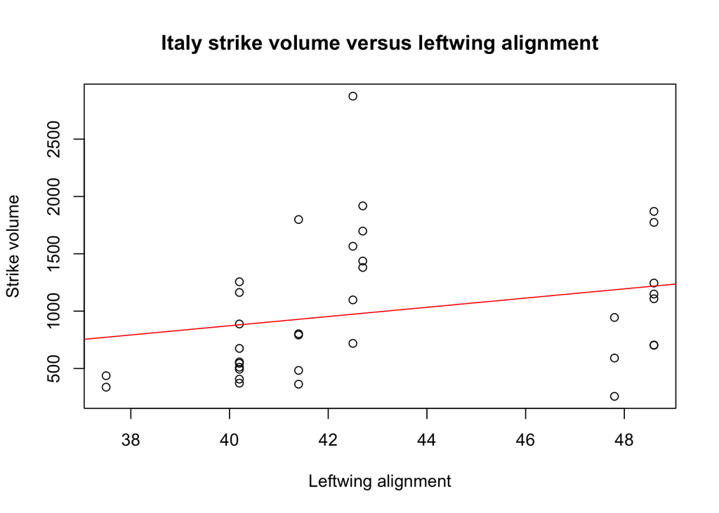

```r
plot(strikes.df.italy$left.parliament, strikes.df.italy$strike.volume,
     main="Italy strike volume versus leftwing alignment",
     ylab="Strike volume", xlab="Leftwing alignment")
abline(coef(italy.lm), col=2)
```

# Functionalization

Now let’s turn this into a function

```r
my.strike.lm = function(country.df) {
  coef(lm(strike.volume ~ left.parliament, data=country.df))
}
my.strike.lm(strikes.df.italy) # New way
```

```
##     (Intercept) left.parliament
##      -738.74531        40.29109
```

```r
coef(italy.lm) # Old way, same result
```

```
##     (Intercept) left.parliament
##      -738.74531        40.29109
```

# Split our data into appropriate chunks

**Step 1**: split our data into appropriate chunks, each of which can be handled by our function. Here, the function `split()` is often helpful: `split(df, f=my.factor)` splits a data frame `df` into several data frames, defined by constant levels of the factor `my.factor`

So we want to split `strikes.df` into 18 smaller data frames, each of which has the data for just one country

```r
strikes.by.country = split(strikes.df, f=strikes.df$country)
class(strikes.by.country) # It's a list
```

```
## [1] "list"
```

```r
names(strikes.by.country) # It has one element for each country
```

```
##  [1] "Australia"   "Austria"     "Belgium"     "Canada"      "Denmark"
##  [6] "Finland"     "France"      "Germany"     "Ireland"     "Italy"
## [11] "Japan"       "Netherlands" "New.Zealand" "Norway"      "Sweden"
## [16] "Switzerland" "UK"          "USA"
```

```r
head(strikes.by.country$Italy) # Same as what we saw before
```

```
##     country year strike.volume unemployment inflation left.parliament
## 311   Italy 1951           437          8.8      14.3            37.5
## 312   Italy 1952           337          9.5       1.9            37.5
## 313   Italy 1953           545         10.0       1.4            40.2
## 314   Italy 1954           493          8.7       2.4            40.2
## 315   Italy 1955           511          7.5       2.3            40.2
## 316   Italy 1956           372          9.3       3.4            40.2
##     centralization density
## 311      0.2513799      NA
## 312      0.2489860      NA
## 313      0.2482739      NA
## 314      0.2466577      NA
## 315      0.2540366      NA
## 316      0.2457069      NA
```

# Apply our function and combine the results

**Steps 2 and 3**: apply our function to each chunk of data, and combine the results. Here, the functions `lapply()` or `sapply()` are often helpful

So we want to apply `my.strikes.lm()` to each data frame in `strikes.by.country`. Think about what the output will be from each function call: vector of length 2 (intercept and slope), so we can use `sapply()`

```r
strikes.coefs = sapply(strikes.by.country, FUN=my.strike.lm)
strikes.coefs
```

```
##                   Australia    Austria    Belgium    Canada     Denmark
## (Intercept)     414.7712254 423.077279 -56.926780 -227.8218 -1399.35735
## left.parliament  -0.8638052  -8.210886   8.447463   17.6766    34.34477
##                  Finland      France   Germany   Ireland      Italy
## (Intercept)     108.2245 202.4261408 95.657134 -94.78661 -738.74531
## left.parliament  12.8422  -0.4255319 -1.312305  55.46721   40.29109
##                     Japan Netherlands New.Zealand     Norway    Sweden
## (Intercept)     964.73750  -32.627678    721.3464 -458.22397 513.16704
## left.parliament -24.07595    1.694387    -10.0106   10.46523  -8.62072
##                 Switzerland        UK        USA
## (Intercept)      -5.1988836 936.10154 111.440651
## left.parliament   0.3203399 -13.42792   5.918647
```

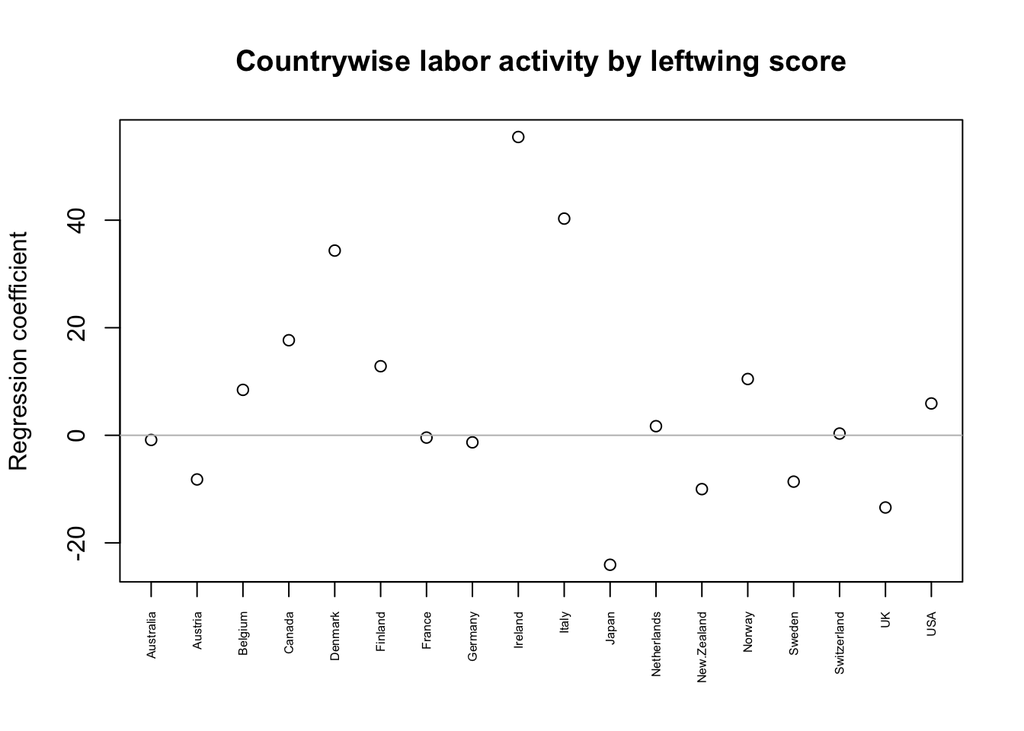

```r
# We don't care about the intercepts, only the slopes (2nd row).
# Some are positive, some are negative! Let's plot them:
plot(1:ncol(strikes.coefs), strikes.coefs[2,], xaxt="n",
     xlab="", ylab="Regression coefficient",
     main="Countrywise labor activity by leftwing score")
axis(side=1, at=1:ncol(strikes.coefs),
     labels=colnames(strikes.coefs), las=2, cex.axis=0.5)
abline(h=0, col="grey")
```

# Part II

*Plyr: `a*ply()` and `l*aply()`*

# The `plyr` package

Most popular R package of all time (most downloads): `plyr`. This is true for a good reason! Provides extremely useful family of apply-like functions

- Advantage over the built-in `apply()` family is its consistency
- All `plyr` functions are of the form `**ply()`
- Replace `**` with characters denoting types:
  - First character: input type, one of `a`, `d`, `l`
  - Second character: output type, one of `a`, `d`, `l`, or `_` (drop)

# `a*ply()`: input is an array

The signature for all `a*ply()` functions is:

```
a*ply(.data, .margins, .fun, ...)
```

- `.data` : an array
- `.margins` : index (or indices) to split the array by
- `.fun` : the function to be applied to each piece
- `...` : additional arguments to be passed to the function

Note that this resembles:

```
apply(X, MARGIN, FUN, ...)
```

# Examples of `a*ply()`

```r
my.array = array(1:27, c(3,3,3))
rownames(my.array) = c("Curly", "Larry", "Moe")
colnames(my.array) = c("Groucho", "Harpo", "Zeppo")
dimnames(my.array)[[3]] = c("Bart", "Lisa", "Maggie")
my.array
```

```
## , , Bart
##
##       Groucho Harpo Zeppo
## Curly       1     4     7
## Larry       2     5     8
## Moe         3     6     9
##
## , , Lisa
##
##       Groucho Harpo Zeppo
## Curly      10    13    16
## Larry      11    14    17
## Moe        12    15    18
##
## , , Maggie
##
##       Groucho Harpo Zeppo
## Curly      19    22    25
## Larry      20    23    26
## Moe        21    24    27
```

```r
library(plyr)
aaply(my.array, 1, sum) # Get back an array
```

```
## Curly Larry   Moe
##   117   126   135
```

```r
adply(my.array, 1, sum) # Get back a data frame
```

```
##      X1  V1
## 1 Curly 117
## 2 Larry 126
## 3   Moe 135
```

```r
alply(my.array, 1, sum) # Get back a list
```

```
## $`1`
## [1] 117
##
## $`2`
## [1] 126
##
## $`3`
## [1] 135
##
## attr(,"split_type")
## [1] "array"
## attr(,"split_labels")
##      X1
## 1 Curly
## 2 Larry
## 3   Moe
```

```r
aaply(my.array, 2:3, sum) # Get back a 3 x 3 array
```

```
##          X2
## X1        Bart Lisa Maggie
##   Groucho    6   33     60
##   Harpo     15   42     69
##   Zeppo     24   51     78
```

```r
adply(my.array, 2:3, sum) # Get back a data frame
```

```
##        X1     X2 V1
## 1 Groucho   Bart  6
## 2   Harpo   Bart 15
## 3   Zeppo   Bart 24
## 4 Groucho   Lisa 33
## 5   Harpo   Lisa 42
## 6   Zeppo   Lisa 51
## 7 Groucho Maggie 60
## 8   Harpo Maggie 69
## 9   Zeppo Maggie 78
```

```r
alply(my.array, 2:3, sum) # Get back a list
```

```
## $`1`
## [1] 6
##
## $`2`
## [1] 15
##
## $`3`
## [1] 24
##
## $`4`
## [1] 33
##
## $`5`
## [1] 42
##
## $`6`
## [1] 51
##
## $`7`
## [1] 60
##
## $`8`
## [1] 69
##
## $`9`
## [1] 78
##
## attr(,"split_type")
## [1] "array"
## attr(,"split_labels")
##        X1     X2
## 1 Groucho   Bart
## 2   Harpo   Bart
## 3   Zeppo   Bart
## 4 Groucho   Lisa
## 5   Harpo   Lisa
## 6   Zeppo   Lisa
## 7 Groucho Maggie
## 8   Harpo Maggie
## 9   Zeppo Maggie
```

# `l*ply()`: input is a list

The signature for all `l*ply()` functions is:

```
l*ply(.data, .fun, ...)
```

- `.data` : a list
- `.fun` : the function to be applied to each element
- `...` : additional arguments to be passed to the function

Note that this resembles:

```
lapply(X, FUN, ...)
```

# Examples of `l*ply()`

```r
my.list = list(nums=rnorm(1000), lets=letters, pops=state.x77[,"Population"])
laply(my.list, range) # Get back an array
```

```
##      1                   2
## [1,] "-3.05554012610841" "2.90906377021611"
## [2,] "a"                 "z"
## [3,] "365"               "21198"
```

```r
ldply(my.list, range) # Get back a data frame
```

```
##    .id                V1               V2
## 1 nums -3.05554012610841 2.90906377021611
## 2 lets                 a                z
## 3 pops               365            21198
```

```r
llply(my.list, range) # Get back a list
```

```
## $nums
## [1] -3.055540  2.909064
##
## $lets
## [1] "a" "z"
##
## $pops
## [1]   365 21198
```

```r
laply(my.list, summary) # Doesn't work! Outputs have different types/lengths
```

```
## Error: Results must have one or more dimensions.
```

```r
ldply(my.list, summary) # Doesn't work! Outputs have different types/lengths
```

```
## Error in list_to_dataframe(res, attr(.data, "split_labels"), .id, id_as_factor): Results do not have equal lengths
```

```r
llply(my.list, summary) # Works just fine
```

```
## $nums
##      Min.   1st Qu.    Median      Mean   3rd Qu.      Max.
## -3.055540 -0.645145 -0.013088  0.000455  0.712293  2.909064
##
## $lets
##    Length     Class      Mode
##        26 character character
##
## $pops
##    Min. 1st Qu.  Median    Mean 3rd Qu.    Max.
##     365    1080    2838    4246    4968   21198
```

# The fourth option for `*`

The fourth option for `*` is `_`: the function `a_ply()` (or `l*ply()`) has no explicit return object, but still runs the given function over the given array (or list), possibly producing side effects

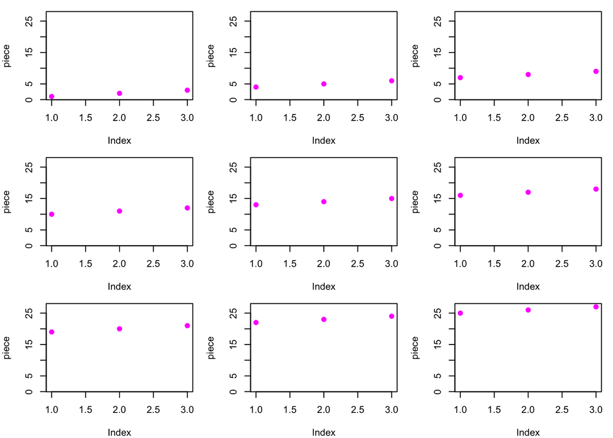

```r
par(mfrow=c(3,3), mar=c(4,4,1,1))
a_ply(my.array, 2:3, plot, ylim=range(my.array), pch=19, col=6)
```

# Part III

*Plyr: `d*ply()`*

# `d*ply()` : the input is a data frame

The signature for all `d*ply()` functions is:

```
d*ply(.data, .variables, .fun, ...)
```

- `.data` : a data frame
- `.variables` : variable (or variables) to split the data frame by
- `.fun` : the function to be applied to each piece
- `...` : additional arguments to be passed to the function

Note that this resembles:

```
tapply(X, INDEX, FUN, ...)
```

# Strikes data set, revisited

```r
# Regression coefficients separately for each country, old way:
strikes.list = split(strikes.df, f=strikes.df$country)
strikes.coefs = sapply(strikes.list, my.strike.lm)
head(strikes.coefs)
```

```
##                   Australia    Austria    Belgium    Canada     Denmark
## (Intercept)     414.7712254 423.077279 -56.926780 -227.8218 -1399.35735
## left.parliament  -0.8638052  -8.210886   8.447463   17.6766    34.34477
##                  Finland      France   Germany   Ireland      Italy
## (Intercept)     108.2245 202.4261408 95.657134 -94.78661 -738.74531
## left.parliament  12.8422  -0.4255319 -1.312305  55.46721   40.29109
##                     Japan Netherlands New.Zealand     Norway    Sweden
## (Intercept)     964.73750  -32.627678    721.3464 -458.22397 513.16704
## left.parliament -24.07595    1.694387    -10.0106   10.46523  -8.62072
##                 Switzerland        UK        USA
## (Intercept)      -5.1988836 936.10154 111.440651
## left.parliament   0.3203399 -13.42792   5.918647
```

```r
# Getting regression coefficient separately for each country, new way:
strikes.coefs.a = daply(strikes.df, .(country), my.strike.lm)
head(strikes.coefs.a) # Get back an array, note the difference to sapply()
```

```
##
## country     (Intercept) left.parliament
##   Australia   414.77123      -0.8638052
##   Austria     423.07728      -8.2108864
##   Belgium     -56.92678       8.4474627
##   Canada     -227.82177      17.6766029
##   Denmark   -1399.35735      34.3447662
##   Finland     108.22451      12.8422018
```

```r
strikes.coefs.d = ddply(strikes.df, .(country), my.strike.lm)
head(strikes.coefs.d) # Get back a data frame
```

```
##     country (Intercept) left.parliament
## 1 Australia   414.77123      -0.8638052
## 2   Austria   423.07728      -8.2108864
## 3   Belgium   -56.92678       8.4474627
## 4    Canada  -227.82177      17.6766029
## 5   Denmark -1399.35735      34.3447662
## 6   Finland   108.22451      12.8422018
```

```r
strikes.coefs.l = dlply(strikes.df, .(country), my.strike.lm)
head(strikes.coefs.l) # Get back a list
```

```
## $Australia
##     (Intercept) left.parliament
##     414.7712254      -0.8638052
##
## $Austria
##     (Intercept) left.parliament
##      423.077279       -8.210886
##
## $Belgium
##     (Intercept) left.parliament
##      -56.926780        8.447463
##
## $Canada
##     (Intercept) left.parliament
##       -227.8218         17.6766
##
## $Denmark
##     (Intercept) left.parliament
##     -1399.35735        34.34477
##
## $Finland
##     (Intercept) left.parliament
##        108.2245         12.8422
```

# Splitting on two (or more) variables

The function `d*ply()` makes it very easy to split on two (or more) variables: we just specify them, separated by a “,” in the `.variables` argument

```r
# First create a variable that indicates whether the year is pre 1975, and add
# it to the data frame
strikes.df$yearPre1975 = strikes.df$year <= 1975
# Then use (say) ddply() to compute regression coefficients for each country
# pre and post 1975
strikes.coefs.1975 = ddply(strikes.df, .(country, yearPre1975), my.strike.lm)
dim(strikes.coefs.1975) # Note that there are 18 x 2 = 36 rows
```

```
## [1] 36  4
```

```r
head(strikes.coefs.1975)
```

```
##     country yearPre1975 (Intercept) left.parliament
## 1 Australia       FALSE   973.34088     -11.8094991
## 2 Australia        TRUE  -169.59900      12.0170866
## 3   Austria       FALSE    19.51823      -0.3470889
## 4   Austria        TRUE   400.83004      -7.7051918
## 5   Belgium       FALSE -4182.06650     148.0049261
## 6   Belgium        TRUE  -103.67439       9.5802824
```

```r
# We can also create factor variables on-the-fly with I(), as we've seen before
strikes.coefs.1975 = ddply(strikes.df, .(country, I(year<=1975)), my.strike.lm)
dim(strikes.coefs.1975) # Again, there are 18 x 2 = 36 rows
```

```
## [1] 36  4
```

```r
head(strikes.coefs.1975)
```

```
##     country I(year <= 1975) (Intercept) left.parliament
## 1 Australia           FALSE   973.34088     -11.8094991
## 2 Australia            TRUE  -169.59900      12.0170866
## 3   Austria           FALSE    19.51823      -0.3470889
## 4   Austria            TRUE   400.83004      -7.7051918
## 5   Belgium           FALSE -4182.06650     148.0049261
## 6   Belgium            TRUE  -103.67439       9.5802824
```

# Parallelization

What happens if we have a really large data set and we want to use split-apply-combine?

If the individual tasks are unrelated, then we should be speed up the computation by performing them **in parallel**

The `plyr` functions make this quite easy: let’s take a look at the full signature for `daply()`:

```
daply(.data, .variables, .fun = NULL, ..., .progress = "none",
  .inform = FALSE, .drop_i = TRUE, .drop_o = TRUE, .parallel = FALSE,
  .paropts = NULL)
```

The second to last argument `.parallel` (default FALSE) is for parallelization. If set to TRUE, then it performs the individual tasks in parallel, using the `foreach` package

The last argument `.paropts` is for more advanced parallelization, these are additional arguments to be passed to `foreach`

For more, read the `foreach` package first. May take some time to set up the parallel backend (this is often system specific)

But once set up, parallelization is simple and beautiful with `**ply()`! The difference is just, e.g.,

```
daply(strikes.df, .(country), my.strike.lm)
```

versus

```
daply(strikes.df, .(country), my.strike.lm, .parallel=TRUE)
```

# Summary

- The split-apply-combine framework is very helpful for breaking up large data analysis tasks, on ragged data, into manageable chunks
  - Step 0: design a function to work on one chunk
  - Step 1: split your data into appropriate chunks
  - Steps 2 and 3: apply your function on each chunk and combine the results (these steps can often be done together)
- Apply functions are very important in the context of the split-apply-combine paradigm
- The `plyr` package makes life easier by making the input and outputs types (array, data frame, or list?) as explicit as possible
  - `a*ply()`: input is an array, `*` specifies output type
  - `l*ply()`: input is a list, `*` specifies output type
  - `d*ply()`: input is a data frame, `*` specifies output type